26 March 2025 - *amasson@cab.inta-csic.es*

# Parallel Computing in Python

Parallel computing enables multiple computations to run simultaneously, improving efficiency and reducing execution time. In Python, we can achieve parallelism using different methods such as multiprocessing, threading, and OpenMPI.

## A simple example

Let's start by defining a big data array on which we'll perform some time-consuming tasks:

```
Shape: (64, 64, 1000)
Memory usage: 31.25 MB
```

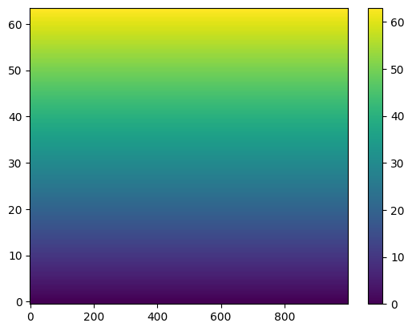

```python
import numpy as np
import matplotlib.pyplot as plt
import time
# %matplotlib widget

# Big data array
data_cube = np.arange(0, 64)[:, None, None] + np.arange(0, 64)[:, None] * np.ones((64,64,1000))

# Print shape
print('Shape:', data_cube.shape)

# Print memory usage
print('Memory usage: {} MB'.format(data_cube.nbytes / 1024**2))

# Plotting
plt.figure()
plt.imshow(data_cube[0, :, :], aspect='auto', origin='lower')
plt.colorbar()
```

Most of the time, simple matrix operations are already optimized for parallel computing using smart math tricks in numpy and scipy. The general rule is therefore to **always first try to apply an operation using numpy or scipy** matricial operations and **avoid "for" loop** as much as possible:

```
Manual implementation:
CPU times: user 1.66 s, sys: 94 µs, total: 1.66 s
Wall time: 1.66 s

Numpy implementation:
CPU times: user 6.07 ms, sys: 18 ms, total: 24.1 ms
Wall time: 24.1 ms

Results are the same: True
```

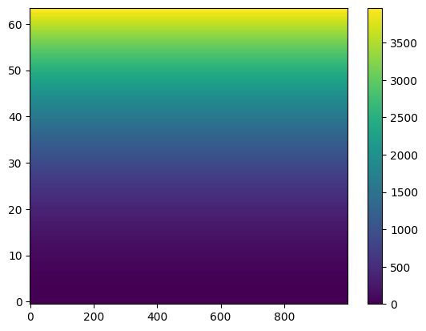

```python
# Manually compute square of the data_cube: this is bad, don't do it
def manual_square(data_cube):
    result = np.nan * np.zeros_like(data_cube)
    for i in range(data_cube.shape[0]):
        for j in range(data_cube.shape[1]):
            for k in range(data_cube.shape[2]):
                result[i, j, k] = data_cube[i, j, k]**2
    return result

# Let's compare how our manual implementation compares to the numpy implementation
print('Manual implementation:')
%time result_manual = manual_square(data_cube)

print('\nNumpy implementation:')
%time result_numpy  = data_cube**2

# Check if the results are the same
print('\nResults are the same:', np.allclose(result_manual, result_numpy))

# Plotting
plt.figure()
plt.imshow(result_manual[0, :, :], aspect='auto', origin='lower')
plt.colorbar()
```

## When linear algebra is not enough

Sometimes we encounter a computationally expensive task that cannot be directly solved with numpy linear algebra magic. Some examples:

- the task relies on a specific program / module that cannot be changed and is called repeatedly
- we need to read/write a very large number of files
- the task cannot be performed through smart numpy/scipy operations
- and many more...

In these cases, using parallel computing can speed-up our tasks (at the cost of a higher CPU & RAM usage). Let's compute exoplanet transmission spectra as an example:

```python
# Here is a function that will do some radiative transfer code calculation of an exoplanet for a given temperature and water abundance
from petitRADTRANS.spectral_model import SpectralModel
from petitRADTRANS import physical_constants as cst
from petitRADTRANS.config.configuration import petitradtrans_config_parser
petitradtrans_config_parser.set_input_data_path('/home/amasson/data/petitRADTRANS/Lines/') # path where line-lists are found

# Load an atmospheric model with given default parameters
model = SpectralModel(
        # Radtrans parameters
        pressures=np.logspace(-6, 2, 100),
        line_species=[
            'H2O',
        ],
        rayleigh_species=['H2', 'He'],
        gas_continuum_contributors=['H2-H2', 'H2-He'],
        wavelength_boundaries=[1.05, 1.2], # microns
        # Model parameters
        # Planet parameters
        planet_radius=1 * cst.r_jup_mean,
        reference_gravity=10 ** 3.5,
        reference_pressure=1e-2,
        filling_species={  # automatically fill the atmosphere with H2 and He, such that the sum of MMRs is equal to 1 and H2/He = 37/12
            'H2': 37,
            'He': 12
        },
        verbose=False,
        line_opacity_mode='lbl'
    )

def compute_spectrum(temperature,h2o_abund):
    # update atmospheric parameters
    model.model_parameters['temperature'] = temperature
    model.model_parameters['imposed_mass_fractions'] = {"H2O": h2o_abund}
    model.update_model_functions_map(update_model_parameters=False)

    # compute transmission spectrum
    wavelengths, transit_radii = model.calculate_spectrum(mode='transmission', update_parameters=True)

    # convert transit radii to Jupiter radii
    transit_radii /= cst.r_jup_mean
    # convert wavelengths to microns
    wavelengths *= 1e4

    return wavelengths[0], transit_radii[0]

# Test a single call of the function:
t0 = time.time()
wavelengths, transit_radii = compute_spectrum(temperature=1000, h2o_abund=1e-4)

print()
print(30*'-')
print(f'Execution time: {time.time() - t0:.2f} s')
print(f'Memory usage: {transit_radii.nbytes / 1024**2:.2f} MB')
print(30*'-')

# Plotting
plt.figure(figsize=(15,5))
plt.plot(wavelengths, transit_radii,lw=0.5)
plt.xlabel('Wavelength (micron)')
plt.ylabel('Transit radius (Rjup)')
plt.title('Transit spectrum for T=1000K and H2O=1e-4')
```

[output not shown]

We now have a function *compute_spectrum* that takes several seconds per call. Computing a thousand spectra (for example to build an interpolation grid) would take hours! Hopefully, we can parallelize the operation...

## Parallelize with *multiprocessing*

Imagine we want to generate thousands of spectra like this and save them in files. This would be a long task! With *multiprocessing*, we can start to parallelize this kind of task on several CPU. To do so, we'll need to define a "worker" function that will perform the task and be called during the parallel computing:

```python
# define a worker to compute and save a spectrum for a given temperature & water abundance
def worker(temperature,h2o_abund):
    # compute spectrum
    wavelengths, transit_radii = compute_spectrum(temperature=temperature, h2o_abund=h2o_abund)
    # save in file
    file_path = f'./parallel_computing_example/{temperature}_K_{h2o_abund}_MMR.txt'
    result = np.array([wavelengths,transit_radii]).T
    np.savetxt(file_path,result,header=f'Wavelength [microns]\tTransit radii [Rjup]')
    print(file_path+' has been saved!')
    # return True if everything ended correctly
    return True

# test worker
%time worker(1000,1e-3)

# load file and plot
wavelengths, transit_radii = np.loadtxt('./parallel_computing_example/1000_K_0.001_MMR.txt').T
plt.figure(figsize=(15,5))
plt.plot(wavelengths,transit_radii, lw=0.5)
plt.xlabel('Wavelength [Microns]')
plt.ylabel('Transit radii [Rjup]')
```

[output not shown]

Now let's parallelize the computation with Pool ! We can check the number of process available on the machine with *os.cpu_count()*:

```python
import os
print(os.cpu_count())
```

[output not shown]

Note however that this displays the total number of cpu, including virtual ones! Hence, using this number as the number of parallel executed tasks may not be optimal, we'll see more about it on the "Thread" part...

- When working on your own computer, you can start by using "*os.cpu_count()-1*" CPU as a starting point.
- **However, when working on a shared cluster or server, don't forget to change the number of CPU otherwise you will slow down the cluster for everyone!!**
- Use *$ htop* on Linux or Task Manager on Windows to monitor RAM & CPU usage

First test without parallel computing:

```python
import multiprocessing as mp

# define the grid extension
N_temp = 4 # nb of spectra to compute per temperature
temperature_grid = np.linspace(500, 5000, N_temp) # K

N_h2o = 4 # nb of spectra to compute per H2O abundance
h2o_abund_grid = np.logspace(-6, -2, N_h2o) # Abundance in Mass Mixing Ratio

# Compute and save files with multiprocess
t0 = time.time()

# without parallelization
for temperature in temperature_grid:
    for h2o_abund in h2o_abund_grid:
        worker(temperature,h2o_abund)

print(30*'-')
print(f'Execution time: {time.time() - t0:.2f} s')
print(30*'-')
```

[output not shown]

Now with multiprocessing:

```python
import multiprocessing as mp

# define the grid extension
N_temp = 4 # nb of spectra to compute per temperature
temperature_grid = np.linspace(500, 5000, N_temp) # K

N_h2o = 4 # nb of spectra to compute per H2O abundance
h2o_abund_grid = np.logspace(-6, -2, N_h2o) # Abundance in Mass Mixing Ratio

# Compute and save files with multiprocess
t0 = time.time()

# This is a safety measure to avoid infinite loops, in particular in Windows where recursive loop can occure. See https://docs.python.org/3/library/multiprocessing.html#multiprocessing-programming
if __name__ == "__main__":
    pool = mp.Pool(processes=os.cpu_count()//2-1)  # Uses all available physical CPUs except one (so the computer is still usable during calculation)
    # assigne task to the Pool
    for temperature in temperature_grid:
        for h2o_abund in h2o_abund_grid:
            pool.apply_async(worker, args=(temperature,h2o_abund))

    # close pool once done
    pool.close()
    # use 'join' to wait for all tasks to be completed
    pool.join()

print(30*'-')
print(f'Execution time: {time.time() - t0:.2f} s')
print(30*'-')
```

[output not shown]

### Filling an array with *mp.Pool*

Imagine now that instead of saving the files we want to store them in an array. Let's try to fill the array using mp.Pool...

```python
# define the empty array
spectrum_size = wavelengths.size # size of a single spectrum
spectra_array = np.zeros((N_temp,N_h2o,spectrum_size))

print('Final array of shape:',spectra_array.shape)
print('Memory usage: {} MB'.format(spectra_array.nbytes / 1024**2))
```

[output not shown]

```python
# define the worker
def worker(spectra_array,temp_index,h2o_index):
    # grab corresponding temperature & h2o_abund
    temperature = temperature_grid[temp_index]
    h2o_abund = h2o_abund_grid[h2o_index]
    # compute the spectrum
    wavelengths, transit_radii = compute_spectrum(temperature=temperature, h2o_abund=h2o_abund)
    # store the spectrum in the array
    spectra_array[temp_index,h2o_index] = transit_radii
    # Return True to indicate that the computation was successful
    return True

# Let's test the worker
t0 = time.time()
worker(spectra_array,0,0)

plt.figure(figsize=(15,5))
plt.plot(wavelengths,spectra_array[0,0],lw=0.5)
plt.xlabel('Wavelength (micron)')
plt.ylabel('Transit radius (Rjup)')

print(30*'-')
print(f'Execution time: {time.time() - t0:.2f} s')
print(30*'-')
```

[output not shown]

```python
# Now let's parallelize the computation with Pool !
import multiprocessing as mp
import os

t0 = time.time()
if __name__ == "__main__":
    pool = mp.Pool(processes=os.cpu_count()//2-1)

    for temp_index in range(N_temp):
        for h2o_index in range(N_h2o):
            pool.apply_async(worker, args=(spectra_array,temp_index,h2o_index))

    pool.close()
    pool.join()

print(30*'-')
print(f'Execution time: {time.time() - t0:.2f} s')
print(30*'-')
```

[output not shown]

```python
# Check that the computation was successful: is there any row with only zeros?
print('Any row with only zeros:', np.any(np.all(spectra_array == 0, axis=-1)))

# Plotting a few random spectra
plt.figure(figsize=(15,5))
for temp_index in np.random.randint(0,N_temp,5):
    for h2o_index in np.random.randint(0,N_h2o,5):
        plt.plot(wavelengths,spectra_array[temp_index,h2o_index]/cst.r_jup_mean,lw=0.5,label=f'T={temperature_grid[temp_index]:.0f}K, H2O={h2o_abund_grid[h2o_index]:.0e}')
plt.xlabel('Wavelength (micron)')
plt.ylabel('Transit radius (Rjup)')
plt.legend()
```

[output not shown]

## Parallelize with *threading* (better in my opinion...)

Using the threading module to perform parallelization allows to spawn individual *threads* and execute them in parallel. The difference with our previous example with mp.Pool is that here we'll define the number of threads to spawn, and we'll let the system assign them on the different CPU.

First we'll need to define a few global variables for the threading to work:

- A *lock* which will allow the *threading* module to lock the memory when a thread is writing on it, hence avoiding multiple thread writing at the same place
- A *counter* (optional) to keep trace on the number of tasks done

```python
import threading

# some global variable for threading
lock = threading.Lock() # Define a lock for safe memory access
counter = 0 # counter for threading monitoring
```

Now we define a worker function just as before, this time also including the "lock" and "counter" global variables

```python
# define the empty array
spectrum_size = wavelengths.size # size of a single spectrum
spectra_array = np.zeros((N_temp,N_h2o,spectrum_size))

print('Final array of shape:',spectra_array.shape)
print('Memory usage: {} MB'.format(spectra_array.nbytes / 1024**2))
```

[output not shown]

```python
# reset counter
counter = 0

# define the worker: here we loop over the provided temperature & h2o indexes, such that each worker work on a sub-part of the grid
def worker(spectra_array,arguments_indexes):
    # grab global threading variables
    global counter, lock

    # grab corresponding temperature & h2o_abund
    for arguments in arguments_indexes:
        temp_index = arguments[0]
        h2o_index  = arguments[1]

        temperature = temperature_grid[temp_index]
        h2o_abund = h2o_abund_grid[h2o_index]

        # compute the spectrum
        wavelengths, transit_radii = compute_spectrum(temperature=temperature, h2o_abund=h2o_abund)

        # update memory, using lock to avoid multiple threads accessing at the same time
        with lock:
            # store the results in the array
            spectra_array[temp_index,h2o_index] = transit_radii
            # update counter
            counter += 1

        # print counter
        print(f'\r{counter}/{temperature_grid.size*h2o_abund_grid.size}',end='',flush=True)

    # Return True to indicate that the computation was successful
    return True

# Let's test the worker
t0 = time.time()
worker(spectra_array,[(0,0)])

plt.figure(figsize=(15,5))
plt.plot(wavelengths,spectra_array[0,0],lw=0.5)
plt.xlabel('Wavelength (micron)')
plt.ylabel('Transit radius (Rjup)')

print()
print(30*'-')
print(f'Execution time: {time.time() - t0:.2f} s')
print(30*'-')
```

[output not shown]

Now the next steps are:

- Set the number of Threads to spawn (somewhat equivalent to the nb of CPU to use in mp.Pool)
- Divide our grid accordingly: we want each Thread to handle a part of the grid to compute
- Launch each Thread on its dedicated sub-part of the grid

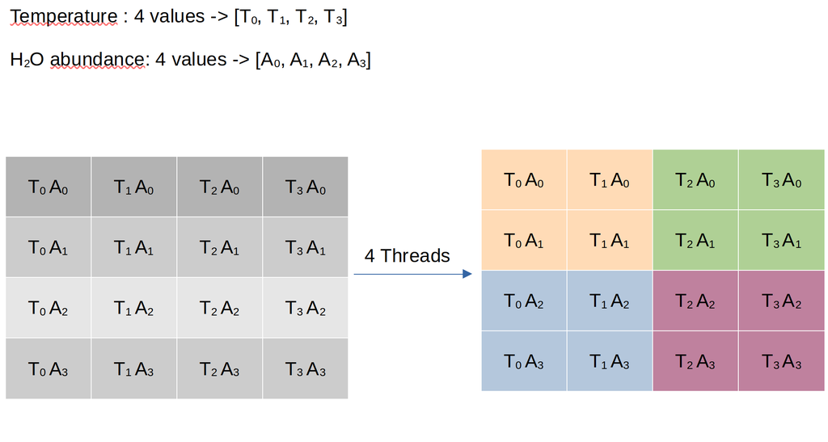

```python
# Set the nb of Threads

# Nb_threads = os.cpu_count()-1
Nb_threads = 8

# we keep a list of the spawned threads to close them later
threads = []

# Divide the grid of computation in equal parts for each thread:
indexes_list = np.array([(temp_index,h2o_index) for temp_index in range(temperature_grid.size) for h2o_index in range(h2o_abund_grid.size)]) # full list of all possible indexes combination
# split the list of index tuples
sub_grids = np.split(indexes_list, Nb_threads) # this is a list of 2D array (one per Thread), each containing an axis with temperature and with the H2O abundances indexes

print('Indexes attributed to Thread n°0:', sub_grids[0])
print()
print('All indexes:', sub_grids)
```

[output not shown]

```python
# Launch parallel computing !

# reset counter
counter = 0
t0 = time.time()

# Assign each thread with one sub-grid of the array
for thread_idx in range(Nb_threads):
    # assign tasks to Threads
    thread = threading.Thread(target=worker, args=(spectra_array,sub_grids[thread_idx]))
    threads.append(thread)
    thread.start()

# Wait for all threads to finish
for thread in threads:
    thread.join()

print()
print(f'Done in {time.time()-t0:.2f}s')
```

[output not shown]

```python
# Check that the computation was successful: is there any row with only zeros?
print('Any row with only zeros:', np.any(np.all(spectra_array == 0, axis=-1)))

# Plotting a few random spectra
plt.figure(figsize=(15,5))
for temp_index in np.random.randint(0,N_temp,5):
    for h2o_index in np.random.randint(0,N_h2o,5):
        plt.plot(wavelengths,spectra_array[temp_index,h2o_index]/cst.r_jup_mean,lw=0.5,label=f'T={temperature_grid[temp_index]:.0f}K, H2O={h2o_abund_grid[h2o_index]:.0e}')
plt.xlabel('Wavelength (micron)')
plt.ylabel('Transit radius (Rjup)')
plt.legend()
```

[output not shown]

Now, how can we optimize the number of Threads? One easy (but time consuming) way is to use brutal force and test the computation time dependence with the nb of Threads:

```python
time_array = []
Nb_thread_list = [1,2,4,8,16]

for Nb_threads in Nb_thread_list:
    print(Nb_threads)
    # reset counter
    counter = 0
    t0 = time.time()

    threads = []

    # Divide the grid of computation in equal parts for each thread:
    indexes_list = np.array([(temp_index,h2o_index) for temp_index in range(temperature_grid.size) for h2o_index in range(h2o_abund_grid.size)]) # full list of all possible indexes combination
    # split the list of index tuples
    sub_grids = np.split(indexes_list, Nb_threads) # this is a list of 2D array (one per Thread), each containing an axis with temperature and with the H2O abundances indexes

    # Assign each thread with one sub-grid of the array
    for thread_idx in range(Nb_threads):
        # assign tasks to Threads
        thread = threading.Thread(target=worker, args=(spectra_array,sub_grids[thread_idx]))
        threads.append(thread)
        thread.start()

    # Wait for all threads to finish
    for thread in threads:
        thread.join()

    time_array.append(time.time()-t0)
```

```python
plt.figure()
plt.plot(Nb_thread_list,time_array)
plt.xlabel('Nb of Threads')
plt.ylabel('Time [s]')
```

[output not shown]

Typical evolution can look like this

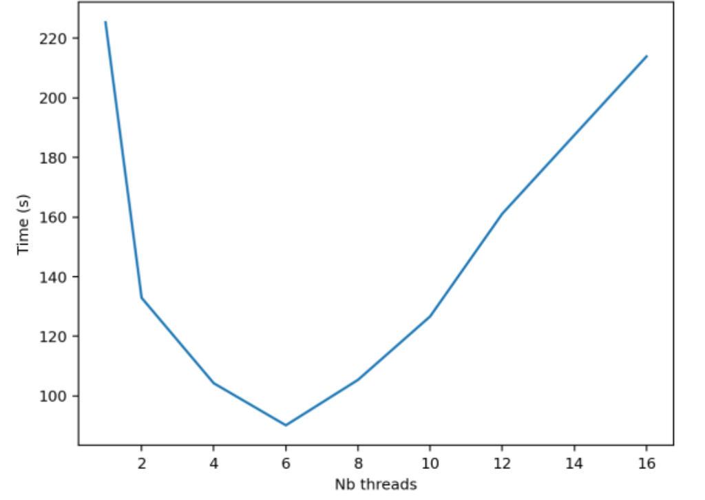

### A word on mpi4py

OpenMPI is also commonly used for distributed computing. Python can utilize OpenMPI via the mpi4py module: $ pip install mpi4py

In the case of natively supported parallelization (like is the case e.g. for Bayesian inference modules like emcee) entire python scripts can be parallelized with the following command from terminal:

$ mpiexec -n Nb_Process python mpi_example.py